# Ames Housing Dataset Regression Analysis (Python Version)

Author

Lucas McGill

Published

November 13, 2025

## Introduction

**Objective:** Develop a multiple linear regression model to predict `SalePrice` using relevant predictor variables, demonstrating iterative model improvement and proper documentation of the prompt engineering process with a Large Language Model (LLM).

**Python Approach:** This document uses Python’s scientific computing stack (pandas, numpy, statsmodels, seaborn, plotly) as an alternative to R for the same analysis.

## Step One: Description of Data

### Data Loading and Initial Exploration

*Prompt 10 [PYTHON]: Load the Ames Housing dataset using pandas and show me the structure and dimensions of the data.*

```python
# Load libraries
import pandas as pd
import numpy as np
import matplotlib.pyplot as plt
import seaborn as sns

# Set seaborn style for better-looking plots
sns.set_theme(style="whitegrid", palette="colorblind")

# Load the housing data
housing = pd.read_csv("amesHousing2011.csv")

# View first few rows
print("First 5 rows of the dataset:")
print(housing.head())

# Check dimensions
print(f"\nDataset dimensions: {housing.shape[0]} rows and {housing.shape[1]} columns")

# View structure of the dataset (data types and non-null counts)
print("\nDataset info:")
print(housing.info())
```

```
First 5 rows of the dataset:
   Order        PID  MSSubClass MSZoning  LotFrontage  LotArea Street Alley  \
0   1498  908154080          20       RL        123.0    47007   Pave   NaN
1   2738  905427030          75       RL         60.0    19800   Pave   NaN
2   2446  528320060          60       RL        118.0    35760   Pave   NaN
3   2667  902400110          75       RM         90.0    22950   Pave   NaN
4   2451  528360050          60       RL        114.0    17242   Pave   NaN

  LotShape LandContour  ... PoolArea PoolQC  Fence MiscFeature MiscVal MoSold  \
0      IR1         Lvl  ...        0    NaN    NaN         NaN       0      7
1      Reg         Lvl  ...        0    NaN    NaN         NaN       0     12
2      IR1         Lvl  ...        0    NaN    NaN         NaN       0      7
3      IR2         Lvl  ...        0    NaN  GdPrv         NaN       0      6
4      IR1         Lvl  ...        0    NaN    NaN         NaN       0      5

```

[output cut: 102 more lines]

**Python Code Explanation:** - `pd.read_csv()` loads the CSV file into a DataFrame (pandas’ equivalent to R’s data frame) - `head()` displays the first 5 rows to see what the data looks like - `shape` attribute shows the dimensions as (rows, columns) - `info()` shows data types (int64, float64, object) and non-null counts for each column - `sns.set_theme()` sets the default styling for seaborn plots (cleaner than matplotlib defaults)

### Summary Statistics

*Prompt 11 [PYTHON]: Generate summary statistics for all variables in the dataset using pandas.*

```python
# Summary statistics for numeric variables
print("Summary statistics for numeric variables:")
print(housing.describe())

# For more detailed stats including categorical variables
print("\n\nDetailed information about all columns:")
print(housing.describe(include='all'))
```

```
Summary statistics for numeric variables:
             Order           PID   MSSubClass  LotFrontage        LotArea  \
count  2925.000000  2.925000e+03  2925.000000  2435.000000    2925.000000
mean   1464.794530  7.143931e+08    57.396581    69.023819   10103.583590
std     846.441706  1.887274e+08    42.668752    22.710918    7781.999124
min       1.000000  5.263011e+08    20.000000    21.000000    1300.000000
25%     732.000000  5.284770e+08    20.000000    58.000000    7438.000000
50%    1463.000000  5.354532e+08    50.000000    68.000000    9428.000000
75%    2199.000000  9.071801e+08    70.000000    80.000000   11515.000000
max    2930.000000  1.007100e+09   190.000000   313.000000  215245.000000

       OverallQual  OverallCond    YearBuilt  YearRemod/Add   MasVnrArea  ...  \
count  2925.000000  2925.000000  2925.000000    2925.000000  2902.000000  ...
mean      6.088205     5.563761  1971.302906    1984.234188   100.710544  ...
std       1.402953     1.112262    30.242474      20.861774   176.034290  ...
min       1.000000     1.000000  1872.000000    1950.000000     0.000000  ...
25%       5.000000     5.000000  1954.000000    1965.000000     0.000000  ...
50%       6.000000     5.000000  1973.000000    1993.000000     0.000000  ...
75%       7.000000     6.000000  2001.000000    2004.000000   164.000000  ...
max      10.000000     9.000000  2010.000000    2010.000000  1600.000000  ...

        WoodDeckSF  OpenPorchSF  EnclosedPorch    3SsnPorch  ScreenPorch  \
count  2925.000000  2925.000000    2925.000000  2925.000000  2925.000000
mean     93.392137    47.166838      23.050940     2.596923    16.029402
std     126.034142    66.571810      64.186809    25.162589    56.131397
min       0.000000     0.000000       0.000000     0.000000     0.000000
25%       0.000000     0.000000       0.000000     0.000000     0.000000
50%       0.000000    27.000000       0.000000     0.000000     0.000000
75%     168.000000    70.000000       0.000000     0.000000     0.000000
max    1424.000000   742.000000    1012.000000   508.000000   576.000000

          PoolArea       MiscVal       MoSold       YrSold      SalePrice
count  2925.000000   2925.000000  2925.000000  2925.000000    2925.000000
mean      1.893333     44.909744     6.216752  2007.791453  180411.574701
std      32.964272    472.237990     2.711541     1.317408   78554.857286
min       0.000000      0.000000     1.000000  2006.000000   12789.000000
25%       0.000000      0.000000     4.000000  2007.000000  129500.000000
50%       0.000000      0.000000     6.000000  2008.000000  160000.000000
75%       0.000000      0.000000     8.000000  2009.000000  213500.000000
max     800.000000  15500.000000    12.000000  2010.000000  625000.000000
```

[output cut: 43 more lines]

```

       SaleType  SaleCondition      SalePrice
count      2925           2925    2925.000000
unique       10              6            NaN
top         WD          Normal            NaN
freq       2534           2412            NaN
mean        NaN            NaN  180411.574701
std         NaN            NaN   78554.857286
min         NaN            NaN   12789.000000
25%         NaN            NaN  129500.000000
50%         NaN            NaN  160000.000000
75%         NaN            NaN  213500.000000
max         NaN            NaN  625000.000000

[11 rows x 82 columns]
```

**Python Code Explanation:** - `describe()` provides descriptive statistics for numeric columns - For numeric variables: count, mean, std, min, 25%, 50%, 75%, max - `describe(include='all')` includes categorical (object) variables with unique counts and top values - Note: pandas shows median as 50th percentile, R shows it separately

### Exploring the Response Variable: Sale Price

*Prompt 12 [PYTHON]: Show me the distribution of SalePrice with a histogram and boxplot using seaborn to identify outliers.*

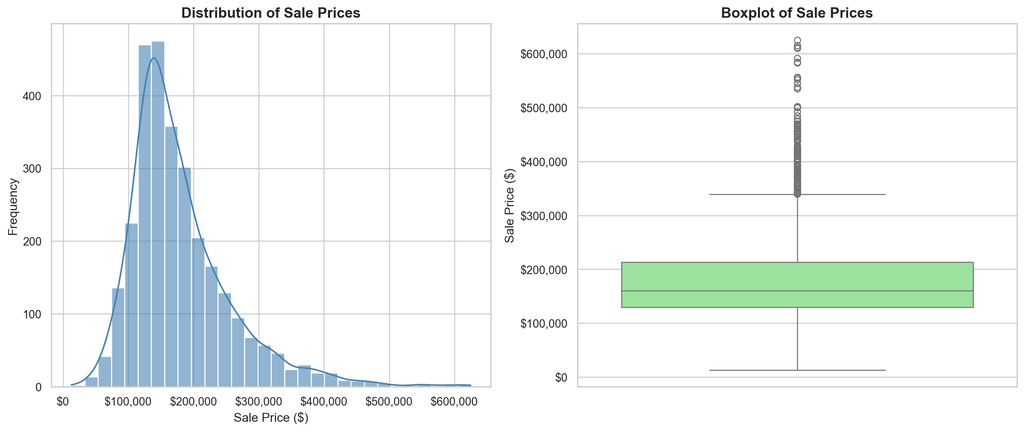

```
Sale Price Summary:
count      2925.000000
mean     180411.574701
std       78554.857286
min       12789.000000
25%      129500.000000
50%      160000.000000
75%      213500.000000
max      625000.000000
Name: SalePrice, dtype: float64

Standard Deviation: $78,554.86

95th percentile of Sale Price: $334,000.00
Number of sales above 95th percentile: 146
```

```python
# Create figure with subplots
fig, (ax1, ax2) = plt.subplots(1, 2, figsize=(14, 6))

# Histogram of Sale Price
sns.histplot(data=housing, x='SalePrice', bins=30, kde=True,
             color='steelblue', alpha=0.6, ax=ax1)
ax1.set_title('Distribution of Sale Prices', fontsize=14, fontweight='bold')
ax1.set_xlabel('Sale Price ($)', fontsize=12)
ax1.set_ylabel('Frequency', fontsize=12)
ax1.xaxis.set_major_formatter(plt.FuncFormatter(lambda x, p: f'${x:,.0f}'))

# Boxplot to identify outliers
sns.boxplot(data=housing, y='SalePrice', color='lightgreen', ax=ax2)
ax2.set_title('Boxplot of Sale Prices', fontsize=14, fontweight='bold')
ax2.set_ylabel('Sale Price ($)', fontsize=12)
ax2.yaxis.set_major_formatter(plt.FuncFormatter(lambda x, p: f'${x:,.0f}'))

plt.tight_layout()
plt.show()

# Summary statistics for SalePrice
print("\nSale Price Summary:")
print(housing['SalePrice'].describe())
print(f"\nStandard Deviation: ${housing['SalePrice'].std():,.2f}")

# Identify potential outliers (above 95th percentile)
price_95 = housing['SalePrice'].quantile(0.95)
print(f"\n95th percentile of Sale Price: ${price_95:,.2f}")
print(f"Number of sales above 95th percentile: {(housing['SalePrice'] > price_95).sum()}")
```

**Observations:** - The distribution appears right-skewed with some high-value outliers - These outliers (mansion sales) may distort our regression model - Professor recommendation: Remove these outliers before modeling

### Exploring Key Predictor Variables

*Prompt 13 [PYTHON]: Show me distributions of the most important predictor variables using seaborn: living area, overall quality, year built, and basement area.*

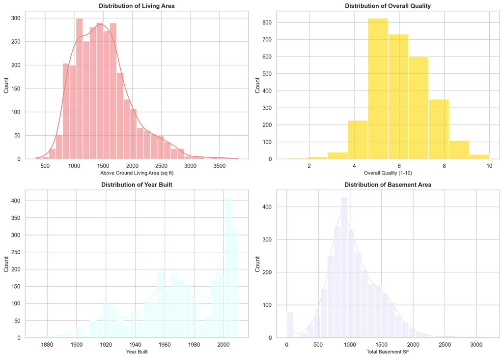

```
Living Area Summary:
count    2925.000000
mean     1493.978803
std       486.273646
min       334.000000
25%      1126.000000
50%      1441.000000
75%      1740.000000
max      3820.000000
Name: GrLivArea, dtype: float64

Overall Quality Summary:
count    2925.000000
mean        6.088205
std         1.402953
min         1.000000
25%         5.000000
50%         6.000000
75%         7.000000
max        10.000000
Name: OverallQual, dtype: float64

Year Built Summary:
count    2925.000000
mean     1971.302906
std        30.242474
min      1872.000000
25%      1954.000000
50%      1973.000000
75%      2001.000000
max      2010.000000
Name: YearBuilt, dtype: float64

Basement Area Summary:
count    2924.000000
mean     1046.852257
std       421.109533
min         0.000000
25%       792.750000
50%       989.500000
75%      1299.250000
max      3206.000000
Name: TotalBsmtSF, dtype: float64
```

```python
# Create 2x2 subplot layout
fig, axes = plt.subplots(2, 2, figsize=(14, 10))

# Living Area (GrLivArea)
sns.histplot(data=housing, x='GrLivArea', bins=30, kde=True,
             color='lightcoral', alpha=0.6, ax=axes[0, 0])
axes[0, 0].set_title('Distribution of Living Area', fontsize=12, fontweight='bold')
axes[0, 0].set_xlabel('Above Ground Living Area (sq ft)', fontsize=10)

# Overall Quality
sns.histplot(data=housing, x='OverallQual', bins=10, kde=False,
             color='gold', alpha=0.6, ax=axes[0, 1])
axes[0, 1].set_title('Distribution of Overall Quality', fontsize=12, fontweight='bold')
axes[0, 1].set_xlabel('Overall Quality (1-10)', fontsize=10)

# Year Built
sns.histplot(data=housing, x='YearBuilt', bins=30, kde=True,
             color='lightcyan', alpha=0.6, ax=axes[1, 0])
axes[1, 0].set_title('Distribution of Year Built', fontsize=12, fontweight='bold')
axes[1, 0].set_xlabel('Year Built', fontsize=10)

# Total Basement Square Feet
sns.histplot(data=housing, x='TotalBsmtSF', bins=30, kde=True,
             color='lavender', alpha=0.6, ax=axes[1, 1])
axes[1, 1].set_title('Distribution of Basement Area', fontsize=12, fontweight='bold')
axes[1, 1].set_xlabel('Total Basement SF', fontsize=10)

plt.tight_layout()
plt.show()

# Summary statistics for key predictors
print("\nLiving Area Summary:")
print(housing['GrLivArea'].describe())

print("\nOverall Quality Summary:")
print(housing['OverallQual'].describe())

print("\nYear Built Summary:")
print(housing['YearBuilt'].describe())

print("\nBasement Area Summary:")
print(housing['TotalBsmtSF'].describe())
```

**Python Code Explanation:** - `plt.subplots(2, 2)` creates a 2×2 grid of axes for multiple plots - Access individual axes with `axes[row, col]` indexing - Each `sns.histplot()` creates a histogram for a key predictor variable - `tight_layout()` automatically adjusts spacing to prevent overlap - Summary statistics help identify the range and central tendency - Note: Python uses zero-based indexing (axes[0, 0]), R uses one-based indexing

### Relationships Between Variables

*Prompt 14 [PYTHON]: Create scatterplots using seaborn showing the relationship between SalePrice and key predictors.*

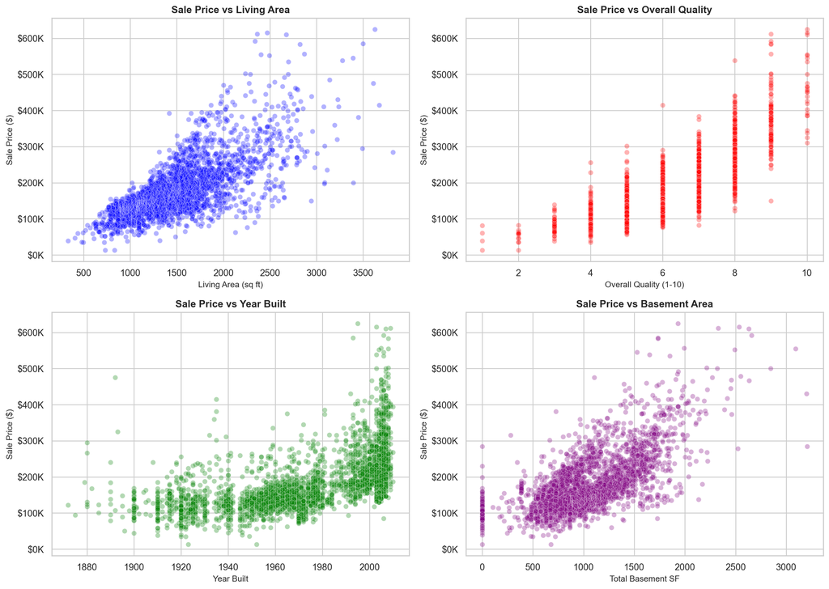

```python
# Create 2x2 subplot layout
fig, axes = plt.subplots(2, 2, figsize=(14, 10))

# SalePrice vs Living Area
sns.scatterplot(data=housing, x='GrLivArea', y='SalePrice',
                alpha=0.3, color='blue', ax=axes[0, 0])
axes[0, 0].set_title('Sale Price vs Living Area', fontsize=12, fontweight='bold')
axes[0, 0].set_xlabel('Living Area (sq ft)', fontsize=10)
axes[0, 0].set_ylabel('Sale Price ($)', fontsize=10)
axes[0, 0].yaxis.set_major_formatter(plt.FuncFormatter(lambda x, p: f'${x/1000:.0f}K'))

# SalePrice vs Overall Quality
sns.scatterplot(data=housing, x='OverallQual', y='SalePrice',
                alpha=0.3, color='red', ax=axes[0, 1])
axes[0, 1].set_title('Sale Price vs Overall Quality', fontsize=12, fontweight='bold')
axes[0, 1].set_xlabel('Overall Quality (1-10)', fontsize=10)
axes[0, 1].set_ylabel('Sale Price ($)', fontsize=10)
axes[0, 1].yaxis.set_major_formatter(plt.FuncFormatter(lambda x, p: f'${x/1000:.0f}K'))

# SalePrice vs Year Built
sns.scatterplot(data=housing, x='YearBuilt', y='SalePrice',
                alpha=0.3, color='green', ax=axes[1, 0])
axes[1, 0].set_title('Sale Price vs Year Built', fontsize=12, fontweight='bold')
axes[1, 0].set_xlabel('Year Built', fontsize=10)
axes[1, 0].set_ylabel('Sale Price ($)', fontsize=10)
axes[1, 0].yaxis.set_major_formatter(plt.FuncFormatter(lambda x, p: f'${x/1000:.0f}K'))

# SalePrice vs Basement Area
sns.scatterplot(data=housing, x='TotalBsmtSF', y='SalePrice',
                alpha=0.3, color='purple', ax=axes[1, 1])
axes[1, 1].set_title('Sale Price vs Basement Area', fontsize=12, fontweight='bold')
axes[1, 1].set_xlabel('Total Basement SF', fontsize=10)
axes[1, 1].set_ylabel('Sale Price ($)', fontsize=10)
axes[1, 1].yaxis.set_major_formatter(plt.FuncFormatter(lambda x, p: f'${x/1000:.0f}K'))

plt.tight_layout()
plt.show()
```

**Python Code Explanation:** - `sns.scatterplot()` creates scatterplots to visualize relationships - `alpha=0.3` creates semi-transparent points to see overlapping observations - We’re looking for: - **Linear relationships**: Points form a straight line pattern - **Non-linear relationships**: Curved patterns (may need transformation) - **Heteroscedasticity**: Spread of points increases with X (funneling) - **Strength**: How tightly points cluster around a pattern

**Expected Observations:** - **Living Area**: Strong positive linear relationship expected - **Overall Quality**: Positive relationship, possibly non-linear (may need log transformation) - **Year Built**: Positive relationship, variance may increase with year (heteroscedasticity)

### Correlation Analysis

*Prompt 15 [PYTHON]: Calculate correlations between SalePrice and numeric predictors using pandas to identify the strongest relationships.*

```
Correlations with Sale Price (sorted by strength):

SalePrice        1.000
OverallQual      0.805
GrLivArea        0.719
TotalBsmtSF      0.659
GarageCars       0.653
GarageArea       0.648
1stFlrSF         0.643
YearBuilt        0.565
YearRemod/Add    0.540
TotRmsAbvGrd     0.498
2ndFlrSF         0.257
BedroomAbvGr     0.140
OverallCond     -0.103
Name: SalePrice, dtype: float64
```

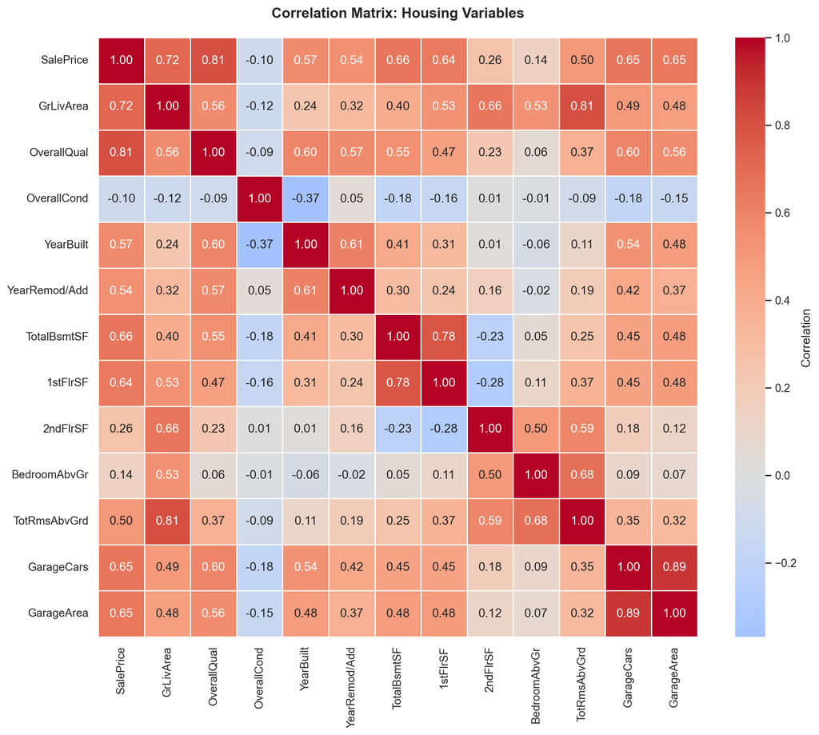

```
Top 10 correlations with SalePrice:
SalePrice        1.000
OverallQual      0.805
GrLivArea        0.719
TotalBsmtSF      0.659
GarageCars       0.653
GarageArea       0.648
1stFlrSF         0.643
YearBuilt        0.565
YearRemod/Add    0.540
TotRmsAbvGrd     0.498
Name: SalePrice, dtype: float64
```

```python
# Select key numeric variables
numeric_vars = ['SalePrice', 'GrLivArea', 'OverallQual', 'OverallCond',
                'YearBuilt', 'YearRemod/Add', 'TotalBsmtSF', '1stFlrSF',
                '2ndFlrSF', 'BedroomAbvGr', 'TotRmsAbvGrd',
                'GarageCars', 'GarageArea']

# Calculate correlation matrix
cor_matrix = housing[numeric_vars].corr()

# Display correlations with SalePrice, sorted by absolute value
cor_with_price = cor_matrix['SalePrice'].sort_values(ascending=False)

print("Correlations with Sale Price (sorted by strength):\n")
print(cor_with_price.round(3))

# Visualize correlation heatmap
fig, ax = plt.subplots(figsize=(12, 10))
sns.heatmap(cor_matrix, annot=True, fmt='.2f', cmap='coolwarm',
            center=0, square=True, linewidths=1,
            cbar_kws={'label': 'Correlation'}, ax=ax)
ax.set_title('Correlation Matrix: Housing Variables',
             fontsize=14, fontweight='bold', pad=20)
plt.tight_layout()
plt.show()

print("\n\nTop 10 correlations with SalePrice:")
print(cor_with_price.head(10).round(3))
```

**Python Code Explanation:** - `corr()` calculates Pearson correlation coefficients between variables - Correlation ranges from -1 (perfect negative) to +1 (perfect positive) - Values close to 0 indicate weak or no linear relationship - `sort_values()` sorts correlations by strength - `sns.heatmap()` creates a visual correlation matrix with color coding - Red indicates positive correlation - Blue indicates negative correlation - White (center=0) indicates no correlation

**Important Note from Professor:** Pairwise correlations can miss important relationships. For example, location variables may have mediating effects on other predictors that won’t show up in simple correlations.

### Missing Data Analysis

*Prompt 16 [PYTHON]: Identify which variables have missing data and how much using pandas.*

```python
# Count missing values per variable
missing_counts = housing.isnull().sum()

# Show only variables with missing data
vars_with_missing = missing_counts[missing_counts > 0]

if len(vars_with_missing) > 0:
    print("Variables with missing data:\n")

    # Calculate percentage missing
    missing_pct = 100 * vars_with_missing / len(housing)

    # Create summary DataFrame
    missing_summary = pd.DataFrame({
        'Variable': vars_with_missing.index,
        'Count': vars_with_missing.values,
        'Percentage': missing_pct.round(2).values
    })

    # Sort by count
    missing_summary = missing_summary.sort_values('Count', ascending=False)

    print(missing_summary.to_string(index=False))
else:
    print("No missing data detected in the dataset.")

# Total missing values
print(f"\nTotal missing values in dataset: {housing.isnull().sum().sum()}")
```

```
Variables with missing data:

    Variable  Count  Percentage
      PoolQC   2914       99.62
 MiscFeature   2820       96.41
       Alley   2727       93.23
       Fence   2354       80.48
  MasVnrType   1774       60.65
 FireplaceQu   1422       48.62
 LotFrontage    490       16.75
  GarageCond    159        5.44
  GarageQual    159        5.44
GarageFinish    159        5.44
 GarageYrBlt    159        5.44
  GarageType    157        5.37
BsmtExposure     83        2.84
BsmtFinType2     81        2.77
    BsmtCond     80        2.74
    BsmtQual     80        2.74
BsmtFinType1     80        2.74
  MasVnrArea     23        0.79
BsmtHalfBath      2        0.07
BsmtFullBath      2        0.07
  BsmtFinSF1      1        0.03
  GarageCars      1        0.03
  GarageArea      1        0.03
 TotalBsmtSF      1        0.03
   BsmtUnfSF      1        0.03
  BsmtFinSF2      1        0.03
  Electrical      1        0.03

Total missing values in dataset: 15732
```

**Python Code Explanation:** - `isnull()` returns True for missing values (NaN, None, etc.) - `sum()` counts missing values for each column - We calculate both counts and percentages to assess severity - Variables with >20% missing may need to be excluded - Variables with <5% missing can use simple imputation - **Professor recommendation**: Use multiple imputation instead of simple median imputation - `to_string(index=False)` prints DataFrame without row indices

## Python vs R: Key Differences in Step One

| Task | R | Python (pandas) |
| --- | --- | --- |
| Load data | `read.csv()` | `pd.read_csv()` |
| First rows | `head()` | `.head()` |
| Dimensions | `nrow()`, `ncol()` | `.shape[0]`, `.shape[1]` |
| Structure | `str()` | `.info()` |
| Summary stats | `summary()` | `.describe()` |
| Missing values | `is.na()` | `.isnull()` or `.isna()` |
| Column sum | `colSums()` | `.sum()` |
| Histogram | `hist()` | `sns.histplot()` |
| Scatter plot | `plot()` | `sns.scatterplot()` |
| Correlation | `cor()` | `.corr()` |

**Key Python Advantages:** - Seaborn produces more polished plots by default - Pandas has more consistent syntax (method chaining) - Better integration with interactive visualization (plotly)

**Key R Advantages:** - More concise syntax for statistical tasks - `summary()` works on all variable types automatically - Statistical focus (designed for data analysis)